# Influencia de los antidepresivos/estimulantes en la muerte por diferentes enfermedades

Seminario Fuentes de datos Biomédicas y Web Semántica

Aitana Crespo Ferrero

Paula Santamaría Velasco

Beatriz Alonso Martín

11 diciembre, 2023

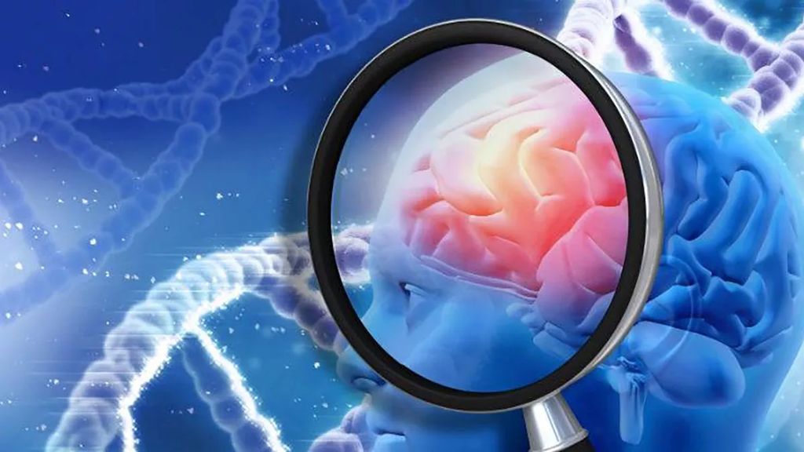

## Indice

1. Introducción
2. Objetivos

   2.1 Objetivo Global

   2.2 Objetivos Específicos
3. Conceptos

   3.1 Antidepresivos/estimulantes

   3.2 Demencia

   3.3 Cáncer de Páncreas

   3.4 Enfermedades isquémicas
4. Importación de datos

   4.1 Importación de librerías

   4.2 Carga de los datos en Excel
5. Tratamiento de datos

   5.1. Defunciones por enfermedad según sexo y comunidad

   5.2. Consumición de antidepresivos/estimulantes según sexo y comunidad

   5.3. Unión de las tablas
6. Gráficos

   6.1. Importación de librerias

   6.2 Objetivos
7. Bibliografía

## 1. Introducción

A lo largo de este seminario vamos a estudiar como afecta el consumo de antidepresivos a la muerte debido a diferentes enfermedades como la demencia, el cáncer de pancreas y las enfermedades isquémicas.

## 2. Objetivos

### 2.1. Objetivo global

El objetivo global de nuestro trabajo es analizar la relacion de antidepresivos/estimulantes con el número de defuncion por enfermedad. Nuestros datos han sido extraídos desde [Datos.gob](https://datos.gob.es/es/catalogo) en formato Excel:

- Número de defunciones por enfermedad según sexo y comunidad autónoma.
- Porcentaje de medicamentos consumidos según sexo y comunidad autónoma.

### 2.2. Objetivos específicos

- Analizar como afectan los antidepresivos/estimulantes al número de defunciones por demencia
- Analizar como afectan los antidepresivos/estimulantes al número de defunciones por cáncer de páncreas
- Analizar como afectan los antidepresivos/estimulantes al número de defunciones por enfermedades isquémicas

## 3. Conceptos

### 3.1. Antidepresivos/estimulantes

Los antidepresivos son medicamentos psicotrópicos que se usan para tratar la depresión.

Los estimulantes son sustancias que aumentan los niveles de actividad cognitiva y motriz.

### 3.2. Demencia

La demencia es una enfermedad que se produce por daños a las celulas del cerebro.Esta lesión celular interfiere con la capacidad de las células cerebrales para comunicarse entre ellas. Cuando estas mismas no pueden comunicarse con normalidad, el pensamiento, el conportamiento y los sentimientos se ven afectados.

Los síntomas de la demencia varian mucho, pero normalmente se ven afetados las siguientes funciones mentales basicas:

- Memoria
- Comunicación y lenguaje
- Capacidad de concentrarse y prestar atencion razonamiento y jucio
- Percepción visual

### 3.3. Cáncer de páncreas

El cáncer de páncreas se produce por la formación incontrolada de células malignas cancerosas en los tejidos del páncreas, por lo que las celulas sanas de este, dejan de funcionar correctamente.

Síntomas:

- Ictericia
- Materia fecal de color claro
- Orina de color oscuro
- Pérdida de peso de razón desconocida
- Pérdida de apetito
- Dolor en el abdomen y espalda
- Sensación de mucho cansancio

### 3.4. Enfermedades isquémicas

Las enfermedades isquémicas producen la reducción del flujo sanguíneo en los tejidos del cuerpo humano, es decir disminuye el nivel de nutrientes y oxígeno en las zonas afectadas.

Síntomas:

- Dolor de cuello o de mandíbula
- Dolor de brazo o de hombro
- Sudoración
- Cansancio
- Dificultad para respirar
- Latido del corazón rápido
- Náuseas y vomitos

## 4. Importacion de datos

### 4.1. Importación de librerias

```r
library(rjson)
library(tidyjson)
library(dplyr)
library(tidyverse)
library(readxl)
```

### 4.2. Carga de los datos en Excel

Hemos escogido el formato Excel para tratar los datos, debido a la complejidad para trabajar con los datos en JSON.

```r
enfermedades2 <- read_excel("DATOS/enfermedades.xlsx")
medicamentos2 <- read_excel("DATOS/medicamentos_consumidos.xlsx")
```

## 5. Tratamiento de los datos

### 5.1. Defunciones por enfermedad según sexo y comunidad

Primero, creamos una tabla llamada “Enfe” igual que la tabla inicial “Enfermedades2”, pero a partir de la fila 7 para quedarnos con los datos que nos interesan.

```r
Enfe <- enfermedades2%>%
  slice(.data = ., 7:nrow(enfermedades2))
```

#### Demencia

Despues, hemos creado un dataframe que contiene las comunidades y los datos de las muertes por demencia según sexo.

**Tabla: muertes por demencia en todas las comunidades (total, hombre y mujer)**

```r
# Primero creamos 4 vectores vacíos
comunidades =c()
totalDem = c()
mujerDem = c()
hombreDem = c()

# Después vamos recorriendo la tabla Enfe y vamos accediendo a las filas en las que ponga "Demencia". Tras esto añadimos al vector vacío llamado "comunidades" las comunidades que hay en nuestra tabla inicial que se encuentran 21 filas antes que la fila "Demencia".
# A continuación, añadimos a los vectores total, mujer y hombre los datos correspondientes que se encuentran en la 1, 2 o 3 filas siguientes a la fila de "Demencia"

for(i in 1:nrow(Enfe)){
    if(!is.na(Enfe$`Defunciones según causa de muerte. Avance enero-mayo 2020`[i]) && Enfe$`Defunciones según causa de muerte. Avance enero-mayo 2020`[i] == "Demencia"){
      comunidades <- append(comunidades,Enfe$`Defunciones según causa de muerte. Avance enero-mayo 2020`[i-21])
      totalDem <- append(totalDem,Enfe$...2[i+1])
      hombreDem <- append(hombreDem,Enfe$...2[i+2])
      mujerDem <-append(mujerDem,Enfe$...2[i+3])
  }
}

# Creamos un dataframe llamado muerteDemencia con los vectores creados anteriormente
muerteDemencia <- data.frame(
  Comunidades = comunidades,
  TotalDemencia = as.integer(totalDem),
  HombreDemencia = as.integer(hombreDem),
  MujerDemencia = as.integer(mujerDem))

muerteDemencia
```

| Comunidades | TotalDemencia | HombreDemencia | MujerDemencia |
| --- | --- | --- | --- |
| Total nacional | 9284 | 2975 | 6309 |
| Andalucía | 972 | 318 | 654 |
| Aragón | 361 | 96 | 265 |
| Asturias, Principado de | 307 | 93 | 214 |
| Balears, Illes | 147 | 52 | 95 |
| Canarias | 262 | 100 | 162 |
| Cantabria | 190 | 62 | 128 |
| Castilla y León | 563 | 192 | 371 |
| Castilla-La Mancha | 433 | 153 | 280 |
| Cataluña | 1665 | 543 | 1122 |

[output cut: 10 more lines]

#### Cáncer de páncreas

Además, creamos un dataframe que contiene las comunidades y los datos de las muertes por cáncer de páncreas según sexo.

**Tabla: muertes por cáncer de páncreas en todas las comunidades (total, hombre y mujer)**

```r
# Primero creamos 3 vectores vacíos, esta vez no creamos el vector comunidad porque nos sirve el creado antes
totalCP = c()
mujerCP = c()
hombreCP = c()


# Después vamos recorriendo la tabla Enfe y vamos accediendo a las filas en las que ponga "Cancer de páncreas", tras esto añadimos al vector vacío llamado "comunidades" las comunidades que hay en nuestra tabla inicial que se encuentran 21 filas antes que la fila "Cancer de páncreas".
# A continuación añadimos a los vectores total, mujer y hombre los datos correspondientes que se encuentran en la 1, 2 o 3 filas siguientes a la fila de "Cancer de páncreas"
for(i in 1:nrow(Enfe)){
    if(!is.na(Enfe$`Defunciones según causa de muerte. Avance enero-mayo 2020`[i]) && Enfe$`Defunciones según causa de muerte. Avance enero-mayo 2020`[i] == "Cáncer de páncreas"){
      totalCP <- append(totalCP,Enfe$...2[i+1])
      hombreCP <- append(hombreCP,Enfe$...2[i+2])
      mujerCP <-append(mujerCP,Enfe$...2[i+3])
  }
}

# Creamos un dataframe llamado muerteCancerPancreas con los vectores creados anteriormente
muerteCancerPancreas <- data.frame(
  Comunidades = comunidades,
  TotalCancerPancreas = suppressWarnings(as.numeric(totalCP)),
  HombreCancerPancreas = suppressWarnings(as.numeric(hombreCP)),
  MujerCancerPancreas = suppressWarnings(as.numeric(mujerCP))
)

muerteCancerPancreas
```

| Comunidades | TotalCancerPancreas | HombreCancerPancreas | MujerCancerPancreas |
| --- | --- | --- | --- |
| Total nacional | 3058 | 1582 | 1476 |
| Andalucía | 425 | 221 | 204 |
| Aragón | 83 | 35 | 48 |
| Asturias, Principado de | 83 | 40 | 43 |
| Balears, Illes | 60 | 39 | 21 |
| Canarias | 122 | 60 | 62 |
| Cantabria | 49 | 22 | 27 |
| Castilla y León | 169 | 92 | 77 |
| Castilla-La Mancha | 129 | 62 | 67 |
| Cataluña | 524 | 271 | 253 |

[output cut: 10 more lines]

#### Enfermedades isquémicas

Por último, hemos creado un dataframe que contiene las comunidades y los datos de las muertes por enfermedades isquémicas según sexo.

**Tabla: muertes por enfermedades isquémicas en todas las comunidades(total, hombre y mujer)**

```r
# Primero creamos 3 vectores vacíos, esta vez no creamos el vector comunidad porque nos sirve el creado antes
totalIsq = c()
mujerIsq = c()
hombreIsq = c()

# Después vamos recorriendo la tabla Enfe y vamos accediendo a las filas en las que ponga "Enfermedades isquémicas del corazón", tras esto añadimos al vector vacío llamado "comunidades" las comunidades que hay en nuestra tabla inicial que se encuentran 21 filas antes que la fila "Enfermedades isquémicas del corazón".
# A continuación añadimos a los vectores total, mujer y hombre los datos correspondientes que se encuentran en la 1, 2 o 3 filas siguientes a la fila de "Enfermedades isquémicas del corazón"
for(i in 1:nrow(Enfe)){
    if(!is.na(Enfe$`Defunciones según causa de muerte. Avance enero-mayo 2020`[i]) && Enfe$`Defunciones según causa de muerte. Avance enero-mayo 2020`[i] == "Enfermedades isquémicas del corazón"){
      totalIsq <- append(totalIsq,Enfe$...2[i+1])
      hombreIsq <- append(hombreIsq,Enfe$...2[i+2])
      mujerIsq <-append(mujerIsq,Enfe$...2[i+3])
  }
}

# Creamos un dataframe llamado muerteIsquemia con los vectores creados anteriormente
muerteIsquemia <- data.frame(
  Comunidades = comunidades,
  TotalIsquemia = as.numeric(totalIsq),
  HombreIsquemia = as.numeric(hombreIsq),
  MujerIsquemia = as.numeric(mujerIsq))

muerteIsquemia
```

| Comunidades | TotalIsquemia | HombreIsquemia | MujerIsquemia |
| --- | --- | --- | --- |
| Total nacional | 13015 | 7877 | 5138 |
| Andalucía | 2630 | 1553 | 1077 |
| Aragón | 402 | 242 | 160 |
| Asturias, Principado de | 442 | 238 | 204 |
| Balears, Illes | 214 | 136 | 78 |
| Canarias | 725 | 426 | 299 |
| Cantabria | 152 | 81 | 71 |
| Castilla y León | 852 | 524 | 328 |
| Castilla-La Mancha | 577 | 351 | 226 |
| Cataluña | 1784 | 1099 | 685 |

[output cut: 10 more lines]

### 5.2. Consumición de antidepresivos/estimulantes según sexo y comunidad

Hemos creado un dataframe que contiene las comunidades y los datos de la consumición de antidepresivos/estimulantes segun sexo.

**Tabla: Consumo de antidepresivos/estimulantes en todas las comunidades(total, hombre y mujer)**

```r
# Creamos un dataframe que contenga las filas de la tabla medicamentos2 que tienen la información que nos interesa
medicamentosAntidepresivos<- data.frame(
  select(.data = medicamentos2,`Asistencia sanitaria: Cifras relativas`)%>%slice(9:28)%>%rename(Comunidades = `Asistencia sanitaria: Cifras relativas`),
  select(.data = medicamentos2,...39)%>%slice(9:28)%>%rename(TotalAntidepresivos =...39),
  select(.data = medicamentos2,...39)%>%slice(30:49)%>%rename(HombreAntidepresivos =...39),
  select(.data = medicamentos2,...39)%>%slice(51:70)%>%rename(MujerAntidepresivos =...39)
)
# Pasamos los valores antes obtenidos a double para usarlos como números
medicamentosAntidepresivos<-medicamentosAntidepresivos %>%
  mutate(TotalAntidepresivos = as.double(TotalAntidepresivos)) %>%
  mutate(HombreAntidepresivos = as.double(HombreAntidepresivos)) %>%
  mutate(MujerAntidepresivos = as.double(MujerAntidepresivos))

medicamentosAntidepresivos
```

| Comunidades | TotalAntidepresivos | HombreAntidepresivos | MujerAntidepresivos |
| --- | --- | --- | --- |
| Total | 4.52 | 2.60 | 6.33 |
| Andalucía | 3.35 | 1.60 | 5.02 |
| Aragón | 4.56 | 2.23 | 6.80 |
| Asturias (Principado de) | 8.21 | 4.06 | 11.98 |
| Balears (Illes) | 1.96 | 3.10 | 0.84 |
| Canarias | 7.24 | 4.41 | 9.99 |
| Cantabria | 3.12 | 1.69 | 4.46 |
| Castilla y León | 4.51 | 2.94 | 6.04 |
| Castilla-La Mancha | 4.24 | 3.07 | 5.42 |
| Cataluña | 4.22 | 2.20 | 6.13 |

[output cut: 10 more lines]

Estos son los datos de la poblacion total y por sexo en 2020 en España sacados de la pagina del Instituto Nacional de Estadística:

```r
poblacionEspaña2020<-47318050
poblacionHombres2020<-23210668
poblacionMujeres2020<-24107382
```

### 5.3. Unión de las tablas

#### Demencia y antidepresivos/estimulantes

Ahora, hacemos la union de los datos de defunciones por demencia y los de medicamentos consumidos. La unión se realiza por la columna “Comunidades” que es la común en las dos tablas.

**Tabla: unión de la consumición de antidepresivos/estimulantes con las muertes por demencia:**

```r
for(i in 1:nrow(medicamentosAntidepresivos)){
  if(medicamentosAntidepresivos$Comunidades[i] != muerteDemencia$Comunidades[i]){
    medicamentosAntidepresivos$Comunidades[i]<- muerteDemencia$Comunidades[i]
  }
}
unionDem <-full_join(x = medicamentosAntidepresivos, y = muerteDemencia, by = c("Comunidades")) %>%
  arrange(.data = ., TotalDemencia, TotalAntidepresivos)%>%
  reframe(Sexo = c("Hombres", "Mujeres", "Total"),
            Demencia = c(sum(HombreDemencia,na.rm = TRUE)*100/poblacionHombres2020, sum(MujerDemencia,na.rm = TRUE)*100/poblacionMujeres2020, sum(TotalDemencia,na.rm = TRUE)*100/poblacionEspaña2020),
            Antidepresivos = c(mean(HombreAntidepresivos), mean(MujerAntidepresivos), mean(TotalAntidepresivos)))%>%
  pivot_longer(names_to = "Variables", values_to = "Porcentajes", cols = (Demencia:Antidepresivos))

unionDem
```

| Sexo | Variables | Porcentajes |
| --- | --- | --- |
| Hombres | Demencia | 0.02563476 |
| Hombres | Antidepresivos | 2.54600000 |
| Mujeres | Demencia | 0.05234081 |
| Mujeres | Antidepresivos | 6.00050000 |
| Total | Demencia | 0.03924084 |
| Total | Antidepresivos | 4.31800000 |

#### Cáncer de páncreas y antidepresivos/estimulantes

Después, hacemos la union de los datos de defunciones por cáncer de páncreas y los de medicamentos consumidos. La unión se realiza por la columna “Comunidades” que es la común en las dos tablas.

**Tabla: unión de la consumición de antidepresivos/estimulantes con las muertes por cancer de pancreas**

```r
for(i in 1:nrow(medicamentosAntidepresivos)){
  if(medicamentosAntidepresivos$Comunidades[i] != muerteCancerPancreas$Comunidades[i]){
    medicamentosAntidepresivos$Comunidades[i]<- muerteCancerPancreas$Comunidades[i]
  }
}

unionPan <-full_join(x = medicamentosAntidepresivos, y = muerteCancerPancreas, by = c("Comunidades")) %>%
  arrange(.data = ., TotalCancerPancreas, TotalAntidepresivos)%>%
  reframe(Sexo = c("Hombres", "Mujeres", "Total"),
            CancerPancreas = c(sum(HombreCancerPancreas, na.rm = TRUE)*100/poblacionHombres2020, sum(MujerCancerPancreas, na.rm = TRUE)*100/poblacionMujeres2020, sum(TotalCancerPancreas, na.rm = TRUE)*100/poblacionEspaña2020),
            Antidepresivos = c(mean(HombreAntidepresivos), mean(MujerAntidepresivos), mean(TotalAntidepresivos)))%>%
  pivot_longer(names_to = "Variables", values_to = "Porcentajes", cols = (CancerPancreas:Antidepresivos))

unionPan
```

| Sexo | Variables | Porcentajes |
| --- | --- | --- |
| Hombres | CancerPancreas | 0.01363166 |
| Hombres | Antidepresivos | 2.54600000 |
| Mujeres | CancerPancreas | 0.01224521 |
| Mujeres | Antidepresivos | 6.00050000 |
| Total | CancerPancreas | 0.01292530 |
| Total | Antidepresivos | 4.31800000 |

#### Enfermedades isquémicas y antidepresivos/estimulantes

Por último, hacemos la union de los datos de defunciones por enfermedades isquémicas y los de medicamentos consumidos. La unión se realiza por la columna “Comunidades” que es la común en las dos tablas.

**Tabla: unión de la consumición de antidepresivos/estimulantes con las muertes por isquemia**

```r
for(i in 1:nrow(medicamentosAntidepresivos)){
  if(medicamentosAntidepresivos$Comunidades[i] != muerteIsquemia$Comunidades[i]){
    medicamentosAntidepresivos$Comunidades[i]<- muerteIsquemia$Comunidades[i]
  }
}

unionIsq <-full_join(x = medicamentosAntidepresivos, y = muerteIsquemia, by = c("Comunidades")) %>%
  arrange(.data = ., TotalIsquemia, TotalAntidepresivos)%>%
  reframe(Sexo = c("Hombres", "Mujeres", "Total"),
            Isquemia = c(sum(HombreIsquemia, na.rm = TRUE)*100/poblacionHombres2020, sum(MujerIsquemia, na.rm = TRUE)*100/poblacionMujeres2020, sum(TotalIsquemia, na.rm = TRUE)*100/poblacionEspaña2020),
            Antidepresivos = c(mean(HombreAntidepresivos), mean(MujerAntidepresivos), mean(TotalAntidepresivos)))%>%
  pivot_longer(names_to = "Variables", values_to = "Porcentajes", cols = (Isquemia:Antidepresivos))

unionIsq
```

| Sexo | Variables | Porcentajes |
| --- | --- | --- |
| Hombres | Isquemia | 0.06787396 |
| Hombres | Antidepresivos | 2.54600000 |
| Mujeres | Isquemia | 0.04262595 |
| Mujeres | Antidepresivos | 6.00050000 |
| Total | Isquemia | 0.05501072 |
| Total | Antidepresivos | 4.31800000 |

## 6. Gráficos

### 6.1. Importación de librerias

```r
library(ggplot2)
library(tidyverse)
```

### 6.2. Objetivos

#### Objetivo 1: Analizar cómo afectan los antidepresivos/estimulantes al número de defunciones por demencia

**Gráfica de antidepresivos/estimulantes con muerte por demencia**

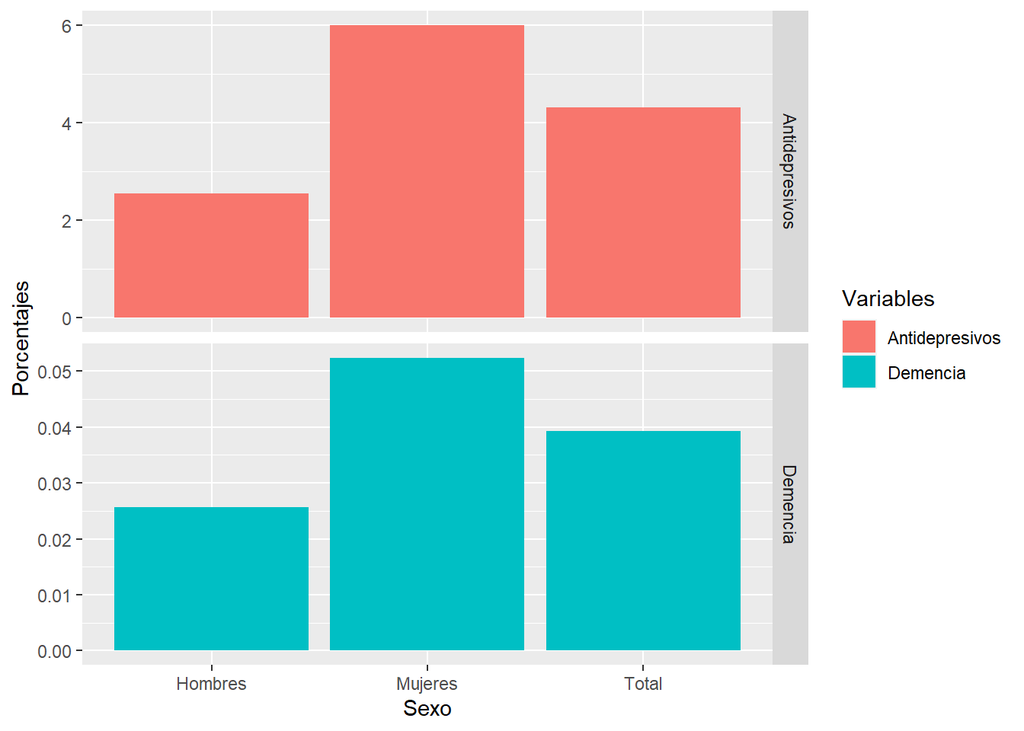

```r
graficaDem<-ggplot(unionDem, aes(fill = Variables, y=Porcentajes, x=Sexo)) +
    geom_bar(position="dodge", stat="identity")
graficaDem+facet_grid("Variables", scales = "free_y")
```

**Conclusiones**:

Vamos a realizar el análisis de la relacion entre el consumo de antidepresivos/estimulantes con la muerte por demecia según sexo:

- Hombres: podemos ver en la gráfica que, a mayor consumo de antidepresivos/estimulantes, mayor numero de muertes por demencia. Esto demuestra una relación directamente proporcional entre estas dos variable.
- Mujeres: podemos ver en la gráfica que, a mayor consumo de antidepresivos/estimulantes, mayor numero de muertes por demencia. En las mujeres este efecto es más notorio y las variables presentan una relación directamente proporcional entre estas dos variable.

Aún así, este análisis no explica completamente la relación entre las dos variables. Es necesario realizar más análisis para reforzar esta idea.

#### Objetivo 2: Analizar cómo afectan los antidepresivos/estimulantes al número de defunciones por cáncer de páncreas

**Gráfica de antidepresivos/estimulantes con muerte por cáncer de páncreas**

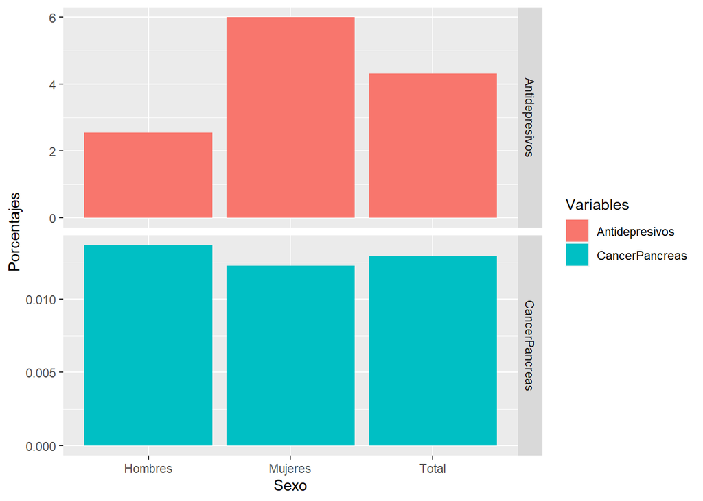

```r
graficaPan<-ggplot(unionPan, aes(fill = Variables, y=Porcentajes, x=Sexo)) +
    geom_bar(position="dodge", stat="identity")
graficaPan+facet_grid("Variables", scales = "free_y")
```

**Conclusiones**:

A continuacion vamos a reliazar el analisis en la relacion entre el consumo de antidepresivos/estimulantes con la muerte por cancer de pancreas segun sexo:

Como podemos observar en la grafica, las muertes por cancer de pancreas en hombres y muejeres es semejante, no obstante respecto al consumo de antidepresivos/estimulantes es evidente que el consumo es mayor en mujeres que en hombres.

**Gráfica de antidepresivos/estimulantes con muerte por isquemia**

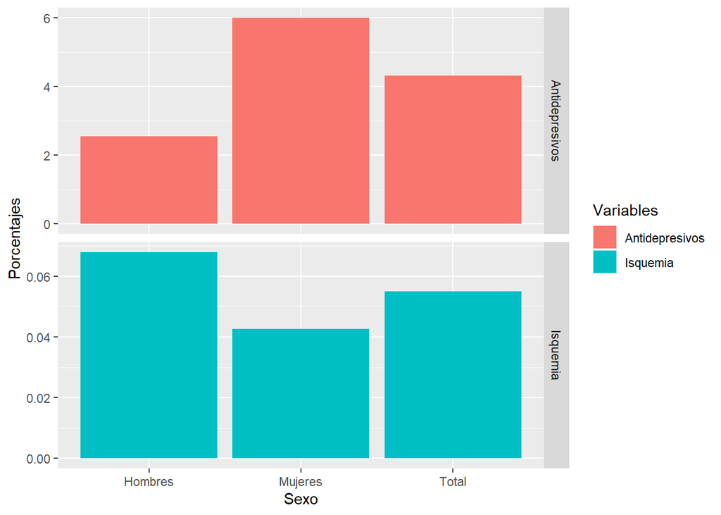

```r
graficaIsq<-ggplot(unionIsq, aes(fill = Variables, y=Porcentajes, x=Sexo)) +
    geom_bar(position="dodge", stat="identity")
graficaIsq+facet_grid("Variables", scales = "free_y")
```

**Conclusiones**:

A pesar de todo esto, es necesario realizar un mayor número de pruebas para determinar de manera concluyente que existe una relación inversamente proporcional entre estas dos variables.

## 7. Bibliografia

- [InformaciónIsquemia](https://www.topdoctors.es/diccionario-medico/isquemia)
- [InformaciónCancerPáncreas](https://www.cancer.gov/espanol/tipos/pancreas/paciente/tratamiento-pancreas-pdq)
- [InformaciónDemencia](https://www.alz.org/alzheimer-demencia/que-es-la-demencia#S%C3%ADntomas)
- [PoblaciónEspaña2020](https://www.ine.es/jaxiT3/Tabla.htm?t=56934)
- [InformaciónAntidepresivos](https://medlineplus.gov/spanish/antidepressants.html)
- [InformaciónEstimulantes](https://es.wikipedia.org/wiki/Estimulante)